# 🌙 Low-Light Image Enhancement & Object Detection

### Zero-DCE + YOLOv8 Pipeline

This notebook implements a complete **unsupervised low-light image enhancement** pipeline using the **Zero-DCE (Zero-Reference Deep Curve Estimation)** model, followed by **YOLOv8 object detection** on the enhanced output.

| Phase | Label | Description |
| --- | --- | --- |
| **Phase 1** | ⚙️ SETUP | Environment Setup & Imports |
| **Phase 2** | 📊 EDA | Dataset Loading & Exploratory Data Analysis |
| **Phase 3** | 🧠 MODEL | Architecture & Loss Functions |
| **Phase 4** | 🏋️ TRAIN | Training Loop (auto-skipped if model exists) |
| **Phase 5** | 🔍 INFERENCE | Enhancement, YOLO Detection & GUI |

## ⚙️ PHASE 1 — Environment Setup

> **Deep Learning Concepts Used in This Phase**

> | Concept | Explanation | |---------|-------------| | **GPU / CUDA** | Neural networks train ~10–100× faster on a GPU because thousands of tensor operations (matrix multiplies, convolutions) are done in parallel. `torch.cuda.is_available()` checks whether a CUDA-compatible GPU is present. | | **PyTorch** | An open-source deep learning framework based on dynamic computation graphs. Unlike TensorFlow 1.x (static graphs), PyTorch builds the graph on-the-fly, making debugging much easier. | | **Hyperparameters** | Settings you choose *before* training that control how the model learns — **not** learned from data. Key ones here: `IMAGE_SIZE` (input resolution), `BATCH_SIZE` (images processed per gradient step), `EPOCHS` (passes over the full dataset), `LR` (learning rate — step size for the optimizer). | | **Dataset paths** | The LOL (Low-Light) dataset contains paired low/normal-light images. Only the *low-light* subfolder (`our485/low`, `eval15/low`) is used because Zero-DCE is **unsupervised** — it needs no ground-truth pairs. |

### 📌 Cell 1 — Core Imports & Device Configuration

**What it does:** Imports all required libraries and detects whether a CUDA GPU is available. All subsequent computation will use the detected device.

```python
import os, glob, time, random
import numpy as np
import matplotlib.pyplot as plt
from PIL import Image
import json
import sys

import torch
import torch.nn as nn
import torch.optim as optim
from torch.utils.data import Dataset, DataLoader
import torchvision.transforms as transforms

device = torch.device("cuda" if torch.cuda.is_available() else "cpu")
print("Using device:", device)
if device.type == "cuda":
    print("GPU:", torch.cuda.get_device_name(0))
```

```
Using device: cuda
GPU: NVIDIA GeForce RTX 4050 Laptop GPU
```

### 📌 Cell 2 — Hyperparameters & Dataset Paths

**What it does:** Central configuration — change paths and training settings here only.

> **Why these values?**
> - `IMAGE_SIZE=256`: Balances detail vs. memory. Zero-DCE is fully-convolutional so any size works at inference.
> - `BATCH_SIZE=16`: Small enough to fit on most GPUs; larger batches give more stable gradient estimates.
> - `EPOCHS=100`: Enough for convergence on a ~500-image dataset.
> - `LR=1e-4`: Standard starting point for Adam optimizer on image tasks.

```python
IMAGE_SIZE = 256
BATCH_SIZE = 16
EPOCHS     = 100
LR         = 1e-4

# ── Update these paths to match your local dataset location ──
TRAIN_DIR = r"C:\Users\dayan\Desktop\DL Sem Project\archive (1)\lol_dataset\our485\low"
TEST_DIR  = r"C:\Users\dayan\Desktop\DL Sem Project\archive (1)\lol_dataset\eval15\low"

# Path where the trained model weights will be saved / loaded from
MODEL_PATH = "best_zero_dce.pth"

print(f"Train dir : {TRAIN_DIR}")
print(f"Test dir  : {TEST_DIR}")
print(f"Model path: {MODEL_PATH}")
```

```
Train dir : C:\Users\dayan\Desktop\DL Sem Project\archive (1)\lol_dataset\our485\low
Test dir  : C:\Users\dayan\Desktop\DL Sem Project\archive (1)\lol_dataset\eval15\low
Model path: best_zero_dce.pth
```

## 📊 PHASE 2 — Exploratory Data Analysis (EDA)

> **What is EDA in Deep Learning?**

> EDA (Exploratory Data Analysis) is the process of *understanding your data before training*. In computer vision this means:
> - Checking dataset size and class balance
> - Visualising sample images to catch corrupted/mislabelled files
> - Analysing pixel intensity distributions to understand the problem severity
> - Measuring image dimensions and aspect ratios to choose `IMAGE_SIZE`
> - Detecting outliers that could destabilise training

> **Why it matters for this project:** Zero-DCE has no reference images to compare against — the loss functions must "know" what counts as well-exposed. EDA tells us the baseline brightness so we can calibrate the exposure loss target (`mean_val=0.6`).

### 📌 Cell 3 — Scan Dataset Files

**What it does:** Collects all `.png` file paths from the training and test directories and reports counts.

```python
train_files = glob.glob(TRAIN_DIR + "/*.png")
test_files  = glob.glob(TEST_DIR  + "/*.png")

print(f"Training Images : {len(train_files)}")
print(f"Test Images     : {len(test_files)}")
```

```
Training Images : 485
Test Images     : 15
```

### 📌 Cell 4 — Visual Sample of Training Images

**What it does:** Displays 8 random training images to visually verify dataset quality and get a feel for the low-light severity.

> **Why this matters:** Always look at your data. Common issues you can catch here: wrong folder loaded, images already enhanced by mistake, extreme underexposure making images pure black, or unexpected resolutions.

[figure not shown]

```python
fig, axes = plt.subplots(2, 4, figsize=(14, 6))
for i, ax in enumerate(axes.flatten()):
    img = Image.open(random.choice(train_files))
    ax.imshow(img)
    ax.axis("off")
plt.suptitle("Sample Low-Light Training Images", fontsize=14, fontweight="bold")
plt.tight_layout()
plt.show()
```

### 📌 Cell 5 — Brightness Distribution Analysis

**What it does:** Measures the average pixel intensity (mean brightness on a 0–255 scale) across 50 randomly sampled training images, then plots a histogram.

> **Deep Learning connection:** This directly informs our **Exposure Loss** design. If the average brightness here is ~40–80 (very dark), targeting `mean_val=0.6` (≈153/255) in the loss is appropriate. If images were already at 200+, the loss target would need adjustment.

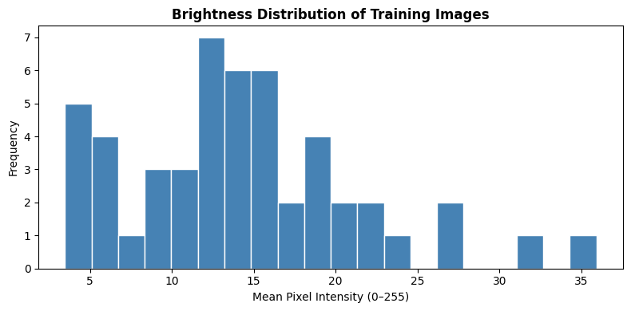

```
Average brightness : 14.32
Min brightness     : 3.48
Max brightness     : 35.92
```

```python
brightness = []
for f in random.sample(train_files, min(50, len(train_files))):
    img = np.array(Image.open(f))
    brightness.append(img.mean())

plt.figure(figsize=(8, 4))
plt.hist(brightness, bins=20, color="steelblue", edgecolor="white")
plt.title("Brightness Distribution of Training Images", fontweight="bold")
plt.xlabel("Mean Pixel Intensity (0–255)")
plt.ylabel("Frequency")
plt.tight_layout()
plt.show()

print(f"Average brightness : {np.mean(brightness):.2f}")
print(f"Min brightness     : {np.min(brightness):.2f}")
print(f"Max brightness     : {np.max(brightness):.2f}")
```

### 📌 Cell 5b — EDA: RGB Channel Distribution

**What it does:** Plots the per-channel (R, G, B) pixel intensity histograms for a sample of training images.

> **Why it matters:** Reveals colour imbalance. In dark environments, sensors often underperform differently per channel — the blue channel may be noisier or the red channel may clip. This motivates the **Colour Constancy Loss** in Zero-DCE, which penalises large differences between channel means.

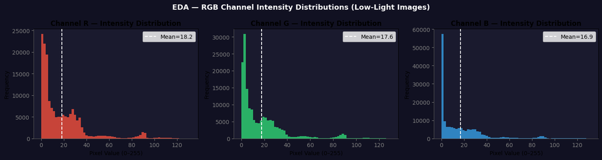

```
Mean R: 18.21  |  Mean G: 17.57  |  Mean B: 16.87
Std  R: 21.00  |  Std  G: 20.86  |  Std  B: 21.70
```

```python
# ── EDA: Per-channel pixel histogram across 10 sample images ──────────────────
sample_imgs = random.sample(train_files, min(10, len(train_files)))
r_vals, g_vals, b_vals = [], [], []

for f in sample_imgs:
    arr = np.array(Image.open(f).resize((128, 128))).astype(np.float32)
    r_vals.append(arr[:,:,0].flatten())
    g_vals.append(arr[:,:,1].flatten())
    b_vals.append(arr[:,:,2].flatten())

r_all = np.concatenate(r_vals)
g_all = np.concatenate(g_vals)
b_all = np.concatenate(b_vals)

fig, axes = plt.subplots(1, 3, figsize=(15, 4))
colors = [("R", r_all, "#e74c3c"), ("G", g_all, "#2ecc71"), ("B", b_all, "#3498db")]

for ax, (ch, vals, col) in zip(axes, colors):
    ax.hist(vals, bins=64, color=col, alpha=0.85, edgecolor="none")
    ax.axvline(vals.mean(), color="white", linestyle="--", linewidth=1.5,
               label=f"Mean={vals.mean():.1f}")
    ax.set_title(f"Channel {ch} — Intensity Distribution", fontweight="bold")
    ax.set_xlabel("Pixel Value (0–255)")
    ax.set_ylabel("Frequency")
    ax.legend()
    ax.set_facecolor("#1a1a2e")
    ax.spines['bottom'].set_color('#555')
    ax.spines['left'].set_color('#555')
    ax.tick_params(colors='gray')

fig.patch.set_facecolor("#111122")
plt.suptitle("EDA — RGB Channel Intensity Distributions (Low-Light Images)",
             fontsize=13, fontweight="bold", color="white")
plt.tight_layout()
plt.show()

print(f"Mean R: {r_all.mean():.2f}  |  Mean G: {g_all.mean():.2f}  |  Mean B: {b_all.mean():.2f}")
print(f"Std  R: {r_all.std():.2f}  |  Std  G: {g_all.std():.2f}  |  Std  B: {b_all.std():.2f}")
```

### 📌 Cell 5c — EDA: Image Resolution Distribution

> **Why it matters:** Variable-resolution datasets are common in the wild. Since we resize everything to `IMAGE_SIZE=256`, images with very different aspect ratios will be distorted. This cell lets you spot if any images are severely non-square, which might justify padding instead of resizing.

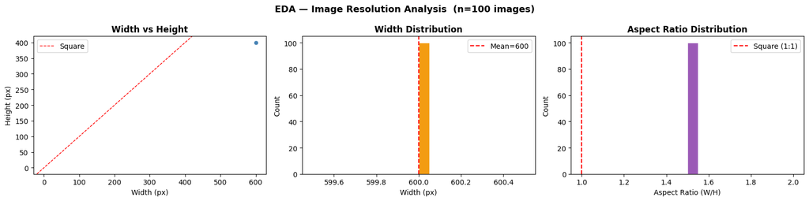

```
Width  — min: 600  max: 600  mean: 600.0
Height — min: 400  max: 400  mean: 400.0
Aspect — min: 1.50  max: 1.50  mean: 1.50
```

```python
# ── EDA: Image resolution scatter plot ──────────────────────────────────────
widths, heights = [], []
sample = random.sample(train_files, min(100, len(train_files)))

for f in sample:
    w, h = Image.open(f).size
    widths.append(w)
    heights.append(h)

widths  = np.array(widths)
heights = np.array(heights)
aspects = widths / heights

fig, axes = plt.subplots(1, 3, figsize=(16, 4))

# Scatter: width vs height
axes[0].scatter(widths, heights, alpha=0.6, color="steelblue", edgecolors="white", linewidth=0.5)
axes[0].set_xlabel("Width (px)")
axes[0].set_ylabel("Height (px)")
axes[0].set_title("Width vs Height", fontweight="bold")
axes[0].axline((0,0), slope=1, color="red", linestyle="--", linewidth=1, label="Square")
axes[0].legend()

# Width distribution
axes[1].hist(widths, bins=20, color="#f39c12", edgecolor="white")
axes[1].set_xlabel("Width (px)")
axes[1].set_ylabel("Count")
axes[1].set_title("Width Distribution", fontweight="bold")
axes[1].axvline(widths.mean(), color="red", linestyle="--", label=f"Mean={widths.mean():.0f}")
axes[1].legend()

# Aspect ratio distribution
axes[2].hist(aspects, bins=20, color="#9b59b6", edgecolor="white")
axes[2].set_xlabel("Aspect Ratio (W/H)")
axes[2].set_ylabel("Count")
axes[2].set_title("Aspect Ratio Distribution", fontweight="bold")
axes[2].axvline(1.0, color="red", linestyle="--", label="Square (1:1)")
axes[2].legend()

plt.suptitle(f"EDA — Image Resolution Analysis  (n={len(sample)} images)",
             fontsize=13, fontweight="bold")
plt.tight_layout()
plt.show()

print(f"Width  — min: {widths.min()}  max: {widths.max()}  mean: {widths.mean():.1f}")
print(f"Height — min: {heights.min()}  max: {heights.max()}  mean: {heights.mean():.1f}")
print(f"Aspect — min: {aspects.min():.2f}  max: {aspects.max():.2f}  mean: {aspects.mean():.2f}")
```

### 📌 Cell 5d — EDA: Per-Image Brightness Box Plot & Outlier Detection

**What it does:** Computes mean brightness for ALL training images, draws a box plot, and flags unusually dark or bright outliers.

> **Why it matters:** Outliers (e.g. completely black images, or accidentally-included normal-light frames) can destabilise training. The interquartile range (IQR) method is a standard statistical technique for outlier detection. Images outside 1.5×IQR from the quartiles are printed so you can inspect or remove them.

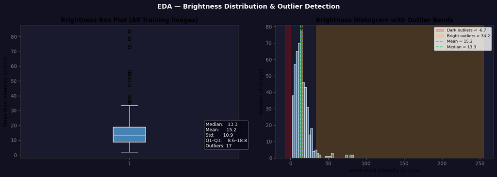

```
Total images: 485
Dark outliers  (brightness < -6.7): 0
Bright outliers (brightness > 34.2): 17
```

```python
# ── EDA: Full brightness analysis + outlier detection ─────────────────────────
all_brightness = []
for f in train_files:
    arr = np.array(Image.open(f))
    all_brightness.append(arr.mean())
all_brightness = np.array(all_brightness)

# IQR-based outlier detection
Q1, Q3 = np.percentile(all_brightness, 25), np.percentile(all_brightness, 75)
IQR    = Q3 - Q1
lo, hi = Q1 - 1.5*IQR, Q3 + 1.5*IQR
outliers_dark   = np.where(all_brightness < lo)[0]
outliers_bright = np.where(all_brightness > hi)[0]

fig, axes = plt.subplots(1, 2, figsize=(14, 5))

# Box plot
bp = axes[0].boxplot(all_brightness, vert=True, patch_artist=True,
                     boxprops=dict(facecolor="steelblue", color="white"),
                     whiskerprops=dict(color="white"),
                     capprops=dict(color="white"),
                     medianprops=dict(color="#f39c12", linewidth=2),
                     flierprops=dict(marker="o", color="#e74c3c", markersize=6))
axes[0].set_title("Brightness Box Plot (All Training Images)", fontweight="bold")
axes[0].set_ylabel("Mean Pixel Intensity (0–255)")
axes[0].set_facecolor("#1a1a2e")
axes[0].tick_params(colors='gray')
for spine in axes[0].spines.values(): spine.set_color('#333')

# Annotate statistics
stats_text = (
    f"Median:   {np.median(all_brightness):.1f}\n"
    f"Mean:     {all_brightness.mean():.1f}\n"
    f"Std:      {all_brightness.std():.1f}\n"
    f"Q1–Q3:    {Q1:.1f}–{Q3:.1f}\n"
    f"Outliers: {len(outliers_dark)+len(outliers_bright)}"
)
axes[0].text(1.35, np.median(all_brightness), stats_text,
             fontsize=9, color="white", va="center",
             bbox=dict(facecolor="#0a0a1a", edgecolor="#555", boxstyle="round"))

# Histogram with IQR bands
axes[1].hist(all_brightness, bins=30, color="steelblue", edgecolor="white", alpha=0.85)
axes[1].axvspan(0, lo, alpha=0.2, color="red", label=f"Dark outliers < {lo:.1f}")
axes[1].axvspan(hi, 255, alpha=0.2, color="orange", label=f"Bright outliers > {hi:.1f}")
axes[1].axvline(all_brightness.mean(), color="#f39c12", linestyle="--", linewidth=1.5,
                label=f"Mean = {all_brightness.mean():.1f}")
axes[1].axvline(np.median(all_brightness), color="#2ecc71", linestyle="--", linewidth=1.5,
                label=f"Median = {np.median(all_brightness):.1f}")
axes[1].set_title("Brightness Histogram with Outlier Bands", fontweight="bold")
axes[1].set_xlabel("Mean Pixel Intensity (0–255)")
axes[1].set_ylabel("Number of Images")
axes[1].legend(fontsize=8)
axes[1].set_facecolor("#1a1a2e")
axes[1].tick_params(colors='gray')
for spine in axes[1].spines.values(): spine.set_color('#333')

fig.patch.set_facecolor("#111122")
plt.suptitle("EDA — Brightness Distribution & Outlier Detection",
             fontsize=13, fontweight="bold", color="white")
plt.tight_layout()
plt.show()

print(f"Total images: {len(all_brightness)}")
print(f"Dark outliers  (brightness < {lo:.1f}): {len(outliers_dark)}")
print(f"Bright outliers (brightness > {hi:.1f}): {len(outliers_bright)}")
if len(outliers_dark):
    print("\nDark outlier files:")
    for i in outliers_dark[:5]: print(f"  {train_files[i]}")
```

### 📌 Cell 5e — EDA: Pixel Intensity Heatmap (Average Image)

**What it does:** Computes the pixel-wise average across a sample of training images to create a "mean image" — essentially a spatial map of where the dataset tends to be darkest.

> **Why it matters:** Dark regions in the mean image often correspond to scene regions (e.g. corners, shadows) where enhancement is most needed. If the mean image is uniformly dark, Zero-DCE must boost the entire frame. Concentrated dark spots suggest local enhancement is more important.

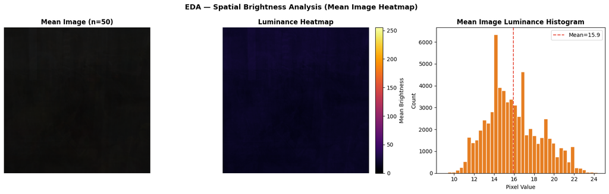

```
Mean luminance of average image: 15.92/255
Darkest pixel in mean image    : 9.00
Brightest pixel in mean image  : 24.33
```

```python
# ── EDA: Mean image (spatial brightness heatmap) ─────────────────────────────
RESIZE = (256, 256)
sum_arr = np.zeros((*RESIZE, 3), dtype=np.float64)
n_sample = min(50, len(train_files))
sample_files = random.sample(train_files, n_sample)

for f in sample_files:
    arr = np.array(Image.open(f).resize(RESIZE)).astype(np.float64)
    sum_arr += arr

mean_img = (sum_arr / n_sample).astype(np.uint8)
gray_mean = mean_img.mean(axis=2)  # luminance channel

fig, axes = plt.subplots(1, 3, figsize=(16, 5))

# Mean image (colour)
axes[0].imshow(mean_img)
axes[0].set_title(f"Mean Image (n={n_sample})", fontweight="bold")
axes[0].axis("off")
axes[0].set_facecolor("#111")

# Grayscale heatmap
im = axes[1].imshow(gray_mean, cmap="inferno", vmin=0, vmax=255)
axes[1].set_title("Luminance Heatmap", fontweight="bold")
axes[1].axis("off")
plt.colorbar(im, ax=axes[1], fraction=0.046, pad=0.04, label="Mean Brightness")

# Histogram of the mean image
axes[2].hist(gray_mean.flatten(), bins=40, color="#e67e22", edgecolor="white")
axes[2].set_title("Mean Image Luminance Histogram", fontweight="bold")
axes[2].set_xlabel("Pixel Value")
axes[2].set_ylabel("Count")
axes[2].axvline(gray_mean.mean(), color="#e74c3c", linestyle="--",
                label=f"Mean={gray_mean.mean():.1f}")
axes[2].legend()

plt.suptitle("EDA — Spatial Brightness Analysis (Mean Image Heatmap)",
             fontsize=13, fontweight="bold")
plt.tight_layout()
plt.show()

print(f"Mean luminance of average image: {gray_mean.mean():.2f}/255")
print(f"Darkest pixel in mean image    : {gray_mean.min():.2f}")
print(f"Brightest pixel in mean image  : {gray_mean.max():.2f}")
```

### 📌 Cell 5f — EDA: Train vs Test Set Comparison

**What it does:** Compares brightness statistics between the training set (`our485`) and test set (`eval15`) to verify they come from similar distributions.

> **Why it matters:** If train and test sets have different brightness profiles, the model may generalise poorly. This is the concept of **distribution shift** — a major practical concern in deploying deep learning models.

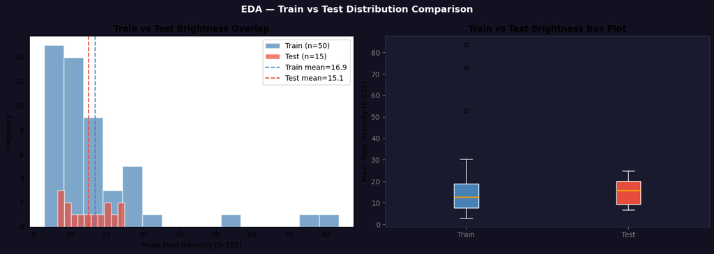

```
Train — mean: 16.9  std: 15.4
Test  — mean: 15.1  std: 6.2
Mean difference (distribution shift): 1.8 intensity units
✅ Distribution similar
```

```python
# ── EDA: Train vs Test brightness comparison ─────────────────────────────────
def sample_brightness(files, n=50):
    sampled = random.sample(files, min(n, len(files)))
    return [np.array(Image.open(f)).mean() for f in sampled]

train_bright = sample_brightness(train_files, 50)
test_bright  = sample_brightness(test_files,  15)

fig, axes = plt.subplots(1, 2, figsize=(14, 5))

# Overlapping histograms
axes[0].hist(train_bright, bins=15, alpha=0.7, color="steelblue",
             edgecolor="white", label=f"Train (n={len(train_bright)})")
axes[0].hist(test_bright,  bins=10, alpha=0.7, color="#e74c3c",
             edgecolor="white", label=f"Test (n={len(test_bright)})")
axes[0].axvline(np.mean(train_bright), color="steelblue",  linestyle="--",
                linewidth=1.5, label=f"Train mean={np.mean(train_bright):.1f}")
axes[0].axvline(np.mean(test_bright),  color="#e74c3c",    linestyle="--",
                linewidth=1.5, label=f"Test mean={np.mean(test_bright):.1f}")
axes[0].set_title("Train vs Test Brightness Overlap", fontweight="bold")
axes[0].set_xlabel("Mean Pixel Intensity (0–255)")
axes[0].set_ylabel("Frequency")
axes[0].legend()

# Box plot side-by-side
bp = axes[1].boxplot([train_bright, test_bright],
                     labels=["Train", "Test"],
                     patch_artist=True,
                     boxprops=dict(color="white"),
                     whiskerprops=dict(color="white"),
                     capprops=dict(color="white"),
                     medianprops=dict(color="#f39c12", linewidth=2),
                     flierprops=dict(marker="o", markersize=5))
bp["boxes"][0].set_facecolor("steelblue")
bp["boxes"][1].set_facecolor("#e74c3c")
axes[1].set_title("Train vs Test Brightness Box Plot", fontweight="bold")
axes[1].set_ylabel("Mean Pixel Intensity (0–255)")
axes[1].set_facecolor("#1a1a2e")
axes[1].tick_params(colors='gray')
for spine in axes[1].spines.values(): spine.set_color('#333')

fig.patch.set_facecolor("#111122")
plt.suptitle("EDA — Train vs Test Distribution Comparison",
             fontsize=13, fontweight="bold", color="white")
plt.tight_layout()
plt.show()

print(f"Train — mean: {np.mean(train_bright):.1f}  std: {np.std(train_bright):.1f}")
print(f"Test  — mean: {np.mean(test_bright):.1f}  std: {np.std(test_bright):.1f}")
diff = abs(np.mean(train_bright) - np.mean(test_bright))
print(f"Mean difference (distribution shift): {diff:.1f} intensity units")
print("✅ Distribution similar" if diff < 20 else "⚠️  Noticeable distribution shift detected")
```

## 🧠 PHASE 3 — Model Architecture & Loss Functions

> **Core Deep Learning Concepts in This Phase**

> | Concept | Explanation | |---------|-------------| | **Convolutional Neural Network (CNN)** | A neural network where each layer applies learned filters (kernels) to detect spatial patterns — edges, textures, shapes. `nn.Conv2d(in, out, kernel_size, padding)` is the building block. | | **Skip Connections (U-Net style)** | Instead of only passing features forward, we concatenate outputs from earlier layers with later ones. This lets the decoder access fine-grained spatial information that would otherwise be lost. Used in DCENet's decoder (`torch.cat([x4, x3], 1)`). | | **Unsupervised / Zero-Reference Learning** | Zero-DCE needs **no paired images** (dark → bright). Instead, it uses physics-inspired loss functions that define "good enhancement" without ever seeing a reference. This is a form of self-supervised learning. | | **Curve Estimation** | Instead of directly predicting an enhanced image, Zero-DCE predicts **curve parameters** — coefficients of the function `x + r*(x² - x)` applied 8 times. This is more stable than direct pixel prediction. | | **DataLoader / mini-batch SGD** | The `DataLoader` splits your dataset into batches. Each batch produces one gradient estimate, which is used to update model weights via backpropagation. |

### 📌 Cell 6 — Dataset Class (`LowLightDataset`)

**What it does:** Defines a PyTorch `Dataset` that loads `.png` images, resizes them to `IMAGE_SIZE×IMAGE_SIZE`, and converts them to normalised `[0,1]` tensors. The `DataLoader` then wraps this for batched training.

```python
class LowLightDataset(Dataset):
    def __init__(self, folder):
        self.files = [os.path.join(folder, f)
                      for f in os.listdir(folder) if f.endswith(".png")]
        self.transform = transforms.Compose([
            transforms.Resize((IMAGE_SIZE, IMAGE_SIZE)),
            transforms.ToTensor()
        ])

    def __len__(self):
        return len(self.files)

    def __getitem__(self, idx):
        img = Image.open(self.files[idx]).convert("RGB")
        return self.transform(img)

train_dataset = LowLightDataset(TRAIN_DIR)
train_loader  = DataLoader(
    train_dataset, batch_size=BATCH_SIZE,
    shuffle=True, num_workers=0, pin_memory=True
)
print(f"DataLoader ready — {len(train_loader)} batches per epoch")
```

```
DataLoader ready — 31 batches per epoch
```

### 📌 Cell 7 — DCENet Architecture (Zero-DCE Backbone)

**What it does:** Defines the `DCENet` class — a 7-layer CNN with U-Net-style skip connections that predicts 24 pixel-wise curve parameters.

> **Architecture Breakdown:**

> ```
>  Input (3 ch)
>      │
>   [Conv1 → ReLU]  x1  ─────────────────────────────────────┐
>      │                                                       │ skip
>   [Conv2 → ReLU]  x2  ──────────────────────────────┐      │
>      │                                               │ skip │
>   [Conv3 → ReLU]  x3  ─────────────────────┐        │      │
>      │                                      │ skip   │      │
>   [Conv4 → ReLU]  x4                        │        │      │
>      │                                      │        │      │
>   [Cat(x4,x3) → Conv5 → ReLU] x5 ──────────┘        │      │
>      │                                               │      │
>   [Cat(x5,x2) → Conv6 → ReLU] x6 ───────────────────┘      │
>      │                                                       │
>   [Cat(x6,x1) → Conv7 → ReLU] x7 ────────────────────────── ┘
>      │
>   [final Conv → Tanh]
>      │
>  Output: 24 channels  (8 iterations × 3 RGB curve maps)
> ```

> **ReLU activation:** `max(0, x)` — introduces non-linearity so the network can learn complex mappings. Without it, stacked convolutions collapse into a single linear operation.

```python
class DCENet(nn.Module):
    def __init__(self):
        super().__init__()
        self.relu = nn.ReLU()
        self.tanh = nn.Tanh()

        # Encoder — feature extraction
        self.conv1 = nn.Conv2d(3,  32, 3, padding=1)
        self.conv2 = nn.Conv2d(32, 32, 3, padding=1)
        self.conv3 = nn.Conv2d(32, 32, 3, padding=1)
        self.conv4 = nn.Conv2d(32, 32, 3, padding=1)

        # Decoder — skip connections double the input channels
        self.conv5 = nn.Conv2d(64, 32, 3, padding=1)
        self.conv6 = nn.Conv2d(64, 32, 3, padding=1)
        self.conv7 = nn.Conv2d(64, 32, 3, padding=1)

        # Output: 24 channels = 8 iterations × 3 RGB curve maps
        self.final = nn.Conv2d(32, 24, 3, padding=1)

    def forward(self, x):
        x1 = self.relu(self.conv1(x))
        x2 = self.relu(self.conv2(x1))
        x3 = self.relu(self.conv3(x2))
        x4 = self.relu(self.conv4(x3))

        # Decoder with skip connections
        x5 = self.relu(self.conv5(torch.cat([x4, x3], 1)))
        x6 = self.relu(self.conv6(torch.cat([x5, x2], 1)))
        x7 = self.relu(self.conv7(torch.cat([x6, x1], 1)))

        return self.tanh(self.final(x7))
```

### 📌 Cell 7b — Architecture Visualisation

**What it does:** Counts and prints model parameters, then visualises the layer structure as a bar chart of output channels per layer.

```
Total parameters    : 90,968
Trainable parameters: 90,968

  conv1     in=3    out=32    params=   896
  conv2     in=32   out=32    params= 9,248
  conv3     in=32   out=32    params= 9,248
  conv4     in=32   out=32    params= 9,248
  conv5     in=64   out=32    params=18,464
  conv6     in=64   out=32    params=18,464
  conv7     in=64   out=32    params=18,464
  final     in=32   out=24    params= 6,936

  ──────────────────────────────────────
  Total (approx) = 90,968
```

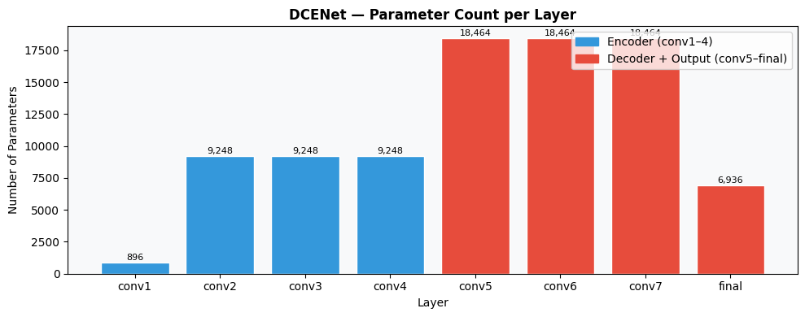

```python
# ── Model parameter count and layer summary ──────────────────────────────────
temp_model = DCENet()

total_params     = sum(p.numel() for p in temp_model.parameters())
trainable_params = sum(p.numel() for p in temp_model.parameters() if p.requires_grad)

print(f"Total parameters    : {total_params:,}")
print(f"Trainable parameters: {trainable_params:,}")
print()

# Layer-by-layer breakdown
layer_names  = ["conv1", "conv2", "conv3", "conv4", "conv5", "conv6", "conv7", "final"]
in_channels  = [3,  32, 32, 32, 64, 64, 64, 32]
out_channels = [32, 32, 32, 32, 32, 32, 32, 24]
layer_params = []

for name, inc, outc in zip(layer_names, in_channels, out_channels):
    params = outc * inc * 3 * 3 + outc   # kernel weights + biases
    layer_params.append(params)
    print(f"  {name:<8}  in={inc:<4} out={outc:<4}  params={params:>6,}")

print(f"\n  {'─'*38}")
print(f"  Total (approx) = {sum(layer_params):,}")

# Bar chart
fig, ax = plt.subplots(figsize=(10, 4))
colors = ["#3498db"]*4 + ["#e74c3c"]*4
bars = ax.bar(layer_names, layer_params, color=colors, edgecolor="white")
ax.set_title("DCENet — Parameter Count per Layer", fontweight="bold")
ax.set_xlabel("Layer")
ax.set_ylabel("Number of Parameters")

# Add value labels on top of each bar
for bar, val in zip(bars, layer_params):
    ax.text(bar.get_x() + bar.get_width()/2, bar.get_height() + 50,
            f"{val:,}", ha="center", va="bottom", fontsize=8)

# Legend for encoder/decoder
from matplotlib.patches import Patch
ax.legend(handles=[Patch(color="#3498db", label="Encoder (conv1–4)"),
                   Patch(color="#e74c3c", label="Decoder + Output (conv5–final)")],
          loc="upper right")

ax.set_facecolor("#f8f9fa")
plt.tight_layout()
plt.show()
```

### 📌 Cell 8 — Loss Functions & Enhancement Curve

**What it does:** Defines the four physics-inspired unsupervised loss functions and the iterative curve enhancement function.

> **Why four losses instead of one?**

> Each loss targets a different failure mode of naive enhancement:

> | Loss | Prevents | Mathematical Intuition | |------|----------|----------------------| | **Illumination Smoothness** | Patchy / noisy curve maps | Penalises large spatial gradients in `r`: `∑|r[x] - r[x+1]|` | | **Spatial Consistency** | Destroying local contrast | Compares local Laplacian between input and output: `∑(∇I_in - ∇I_out)²` | | **Colour Constancy** | Colour shift / tint | Penalises unequal RGB means: `√((R-G)² + (R-B)² + (G-B)²)` | | **Exposure** | Too dark or too bright | Pushes average patch brightness toward 0.6: `∑(pool(x) - 0.6)²` |

```python
# ── Iterative curve enhancement (applies 8 rounds of adjustment) ──────────────
def enhance(x, r):
    for i in range(0, 24, 3):
        r_i = r[:, i:i+3, :, :]
        x = x + r_i * (x * x - x)
    return x

# ── Spatial smoothness of the curve map ────────────────────────────────────────
def smoothness_loss(x):
    return (torch.mean(torch.abs(x[:, :, :, :-1] - x[:, :, :, 1:])) +
            torch.mean(torch.abs(x[:, :, :-1, :] - x[:, :, 1:, :])))

# ── RGB channel balance ─────────────────────────────────────────────────────────
def color_constancy(x):
    mean  = torch.mean(x, dim=(2, 3), keepdim=True)
    r, g, b = mean[:, 0], mean[:, 1], mean[:, 2]
    return torch.sqrt((r - g)**2 + (r - b)**2 + (g - b)**2)

# ── Well-exposedness: push patches toward mean_val ─────────────────────────────
def exposure_loss(x, mean_val=0.6):
    x    = torch.mean(x, dim=1, keepdim=True)
    pool = nn.AvgPool2d(16)(x)
    return torch.mean((pool - mean_val)**2)

# ── Local contrast preservation ─────────────────────────────────────────────────
class SpatialConsistencyLoss(nn.Module):
    def __init__(self):
        super().__init__()
        self.kernel = torch.tensor([[[[0, -1, 0], [0, 1, 0], [0, 0, 0]]]], dtype=torch.float32)

    def forward(self, x, y):
        k = self.kernel.to(x.device)
        return torch.mean(
            (nn.functional.conv2d(x.mean(1, True), k, padding=1) -
             nn.functional.conv2d(y.mean(1, True), k, padding=1))**2
        )

print("✅ Loss functions defined")
```

```
✅ Loss functions defined
```

### 📌 Cell 8b — Loss Function Visualisation

**What it does:** Visualises how the enhancement curve behaves for different values of the curve parameter `r`, so you can intuit what DCENet is learning to predict.

[figure not shown]

```python
# ── Visualise the Zero-DCE curve formula for different r values ──────────────
x = np.linspace(0, 1, 256)

fig, axes = plt.subplots(1, 2, figsize=(14, 5))

# Left: single-iteration curve
ax = axes[0]
for r_val, col, lbl in [(-0.8, "#e74c3c", "r=−0.8 (darken)"),
                         (-0.4, "#e67e22", "r=−0.4"),
                         ( 0.0, "#95a5a6", "r= 0.0 (identity)"),
                         ( 0.4, "#3498db", "r=+0.4"),
                         ( 0.8, "#2ecc71", "r=+0.8 (brighten)")]:
    y = x + r_val * (x**2 - x)
    ax.plot(x, y, color=col, linewidth=2, label=lbl)

ax.plot([0,1],[0,1], "k--", linewidth=1, alpha=0.4, label="Identity (no change)")
ax.set_title("Single Iteration Enhancement Curve\n$x_{new} = x + r(x^2 - x)$",
             fontweight="bold")
ax.set_xlabel("Input Pixel Value")
ax.set_ylabel("Output Pixel Value")
ax.legend(fontsize=8)
ax.set_xlim(0, 1); ax.set_ylim(-0.1, 1.1)
ax.grid(True, linestyle="--", alpha=0.3)

# Right: 8 iterations with r=+0.5
ax2 = axes[1]
r_val = 0.5
x_iter = x.copy()
for iteration in range(8):
    x_iter = x_iter + r_val * (x_iter**2 - x_iter)
    if iteration in [0, 1, 3, 7]:
        alpha = 0.3 + 0.7*(iteration/7)
        ax2.plot(x, x_iter, linewidth=1.5, alpha=alpha,
                 label=f"After iter {iteration+1}")

ax2.plot([0,1],[0,1], "k--", linewidth=1, alpha=0.4, label="Identity")
ax2.set_title("Iterative Enhancement (r=+0.5, 8 iterations)\nEach pass brightens further",
              fontweight="bold")
ax2.set_xlabel("Input Pixel Value")
ax2.set_ylabel("Output Pixel Value")
ax2.legend(fontsize=8)
ax2.set_xlim(0, 1); ax2.set_ylim(0, 1.05)
ax2.grid(True, linestyle="--", alpha=0.3)

plt.suptitle("Zero-DCE Enhancement Curve Behaviour", fontsize=13, fontweight="bold")
plt.tight_layout()
plt.show()
```

## 🏋️ PHASE 4 — Training (Smart Resume)

> **Core Deep Learning Concepts in This Phase**

> | Concept | Explanation | |---------|-------------| | **Forward Pass** | Feed input through the network to get a prediction: `r = model(img)` → `enhanced = enhance(img, r)`. | | **Loss Computation** | Calculate how wrong the prediction is using the four loss functions. | | **Backpropagation** | Compute gradients: how much each weight contributed to the error. `loss.backward()` | | **Optimiser Step** | Adjust weights in the direction that reduces loss. `optimizer.step()` uses Adam (adaptive learning rates per parameter). | | **Epoch** | One complete pass through the entire training dataset. We log per-epoch loss to track convergence. | | **Checkpoint / Best Model** | Save the model whenever the loss reaches a new minimum. This guards against overfitting later in training. | | **`model.eval()` vs `model.train()`** | `.train()` enables dropout and batch norm training modes. `.eval()` disables them for inference. Always switch before inference! |

### 📌 Cell 9 — Train or Load Saved Model

**What it does:** Checks if `best_zero_dce.pth` already exists. If yes, loads it and skips training. If no, trains from scratch, logs all loss components, and saves the best checkpoint.

```python
model           = DCENet().to(device)
spatial_loss_fn = SpatialConsistencyLoss()

# ── Check if a saved model already exists ──────────────────────────────────
if os.path.exists(MODEL_PATH):
    print(f"✅ Saved model found at '{MODEL_PATH}' — loading weights, skipping training.")
    model.load_state_dict(torch.load(MODEL_PATH, map_location=device))
    model.eval()
    loss_log = None   # no training log available when loading
else:
    print(f"⚠️  No saved model found. Starting training for {EPOCHS} epochs...")
    optimizer = optim.Adam(model.parameters(), lr=LR)

    loss_log = {
        "total_loss": [], "illumination_smoothness_loss": [],
        "spatial_constancy_loss": [], "color_constancy_loss": [], "exposure_loss": []
    }
    best_loss = float("inf")

    for epoch in range(EPOCHS):
        model.train()
        total, smooth, spatial, color, exposure = 0, 0, 0, 0, 0

        for img in train_loader:
            img      = img.to(device)
            r        = model(img)
            enhanced = enhance(img, r)

            # Loss weights are tuned to balance each component
            l_s  = 200 * smoothness_loss(r)       # smoothness needs high weight
            l_sp = spatial_loss_fn(enhanced, img)  # already scaled 0–1
            l_c  = 5   * torch.mean(color_constancy(enhanced))
            l_e  = 10  * exposure_loss(enhanced)
            loss = l_s + l_sp + l_c + l_e

            optimizer.zero_grad()   # clear previous gradients
            loss.backward()         # compute gradients via backprop
            optimizer.step()        # update weights (Adam)

            total    += loss.item()
            smooth   += l_s.item()
            spatial  += l_sp.item()
            color    += l_c.item()
            exposure += l_e.item()

        n = len(train_loader)
        loss_log["total_loss"].append(total / n)
        loss_log["illumination_smoothness_loss"].append(smooth / n)
        loss_log["spatial_constancy_loss"].append(spatial / n)
        loss_log["color_constancy_loss"].append(color / n)
        loss_log["exposure_loss"].append(exposure / n)

        print(f"Epoch [{epoch+1:>3}/{EPOCHS}]  Loss: {total/n:.4f}")

        if total / n < best_loss:
            best_loss = total / n
            torch.save(model.state_dict(), MODEL_PATH)
            print(f"              💾 New best model saved (loss={best_loss:.4f})")

    model.eval()
    print(f"\n✅ Training complete. Best loss: {best_loss:.4f}")
```

```
✅ Saved model found at 'best_zero_dce.pth' — loading weights, skipping training.
```

### 📌 Cell 10 — Training Loss Curves

**What it does:** Plots all five loss curves (total + each component) across epochs. Skipped if a pre-trained model was loaded.

> **How to read loss curves:**
> - Steadily decreasing = model learning well ✅
> - Loss plateaus early = learning rate too low, or model capacity too small ⚠️
> - Loss spikes/oscillates = learning rate too high ❌
> - Total loss drops but one component doesn't = that loss weight may need adjustment

```python
if loss_log is not None:
    fig, axes = plt.subplots(2, 3, figsize=(16, 8))
    axes = axes.flatten()
    names = list(loss_log.keys())

    for i, name in enumerate(names):
        axes[i].plot(loss_log[name], color="steelblue", linewidth=1.5)
        axes[i].set_title(name.replace("_", " ").title(), fontweight="bold")
        axes[i].set_xlabel("Epoch")
        axes[i].set_ylabel("Loss")
        axes[i].grid(True, linestyle="--", alpha=0.5)

    # hide the 6th empty subplot
    axes[-1].set_visible(False)
    plt.suptitle("Training Loss Curves — Zero-DCE", fontsize=14, fontweight="bold")
    plt.tight_layout()
    plt.show()
else:
    print("ℹ️  Pre-trained model was loaded — no training log to display.")
```

```
ℹ️  Pre-trained model was loaded — no training log to display.
```

## 🔍 PHASE 5 — Inference, YOLO Detection & Interactive GUI

> **Core Deep Learning Concepts in This Phase**

> | Concept | Explanation | |---------|-------------| | **Inference / Forward Pass only** | At test time we don't compute gradients. `torch.no_grad()` disables gradient tracking → less memory, faster computation. | | **YOLOv8 (You Only Look Once)** | A real-time single-stage object detector. Unlike two-stage detectors (R-CNN), YOLO predicts bounding boxes and class probabilities in one forward pass through the network. | | **Transfer Learning** | YOLOv8 was pre-trained on COCO (80 classes, 330K images). We use it directly without re-training — this is called **zero-shot** transfer. The low-light enhancement improves its accuracy without any YOLO fine-tuning. | | **Confidence Threshold** | YOLO outputs a confidence score (0–1) per detection. We only keep detections above `conf=0.15` (15%). Lower threshold → more detections, but more false positives. | | **NMS (Non-Maximum Suppression)** | When multiple overlapping boxes detect the same object, NMS keeps only the highest-confidence one. Handled internally by YOLO. |

### 📌 Cell 11 — Install YOLOv8

**What it does:** Installs the `ultralytics` package (which provides the YOLOv8 API) into the active kernel. Run once.

```python
import sys
import subprocess
subprocess.run([sys.executable, "-m", "pip", "install", "ultralytics", "--quiet"], check=True)
print("✅ Ultralytics (YOLOv8) ready")
```

```
✅ Ultralytics (YOLOv8) ready
```

### 📌 Cell 12 — Load YOLOv8 Model

**What it does:** Loads the **YOLOv8-small** model weights. First run downloads ~22 MB from the internet automatically.

> **Model size tradeoff:** YOLOv8 comes in nano/small/medium/large/xlarge variants. We use `yolov8s.pt` (small) — better accuracy than nano, still fast enough for interactive use.

```python
import cv2
from ultralytics import YOLO

yolo_model = YOLO("yolov8s.pt")   # upgraded from nano → small, better accuracy
print("✅ YOLOv8 small loaded")
```

```
✅ YOLOv8 small loaded
```

### 📌 Cell 13 — Inference & Detection Helper Functions

**What it does:** Defines two helper functions:

- `infer(path_or_pil)` — runs Zero-DCE on any image and returns (original PIL, enhanced numpy array)
- `detect_on_enhanced(enhanced_np)` — runs YOLOv8 on the enhanced image and returns annotated RGB + results object

> **Key implementation detail:** Enhanced images are resized back to the **original resolution** before YOLO detection. This matters because YOLO was trained on ~640×640 images; feeding it 256×256 (our training size) loses detail and degrades detection accuracy.

```python
def infer(path_or_pil):
    img = Image.open(path_or_pil).convert("RGB") if isinstance(path_or_pil, str) else path_or_pil

    tfm = transforms.Compose([
        transforms.Resize((IMAGE_SIZE, IMAGE_SIZE)),
        transforms.ToTensor()
    ])
    x = tfm(img).unsqueeze(0).to(device)
    with torch.no_grad():              # no gradients needed at inference time
        r   = model(x)
        out = enhance(x, r)

    enhanced_small = out.squeeze().cpu().permute(1, 2, 0).numpy()
    enhanced_small = np.clip(enhanced_small, 0, 1)

    # Resize enhanced output back to original resolution for better YOLO detection
    orig_w, orig_h = img.size
    enhanced_fullres = np.array(
        Image.fromarray((enhanced_small * 255).astype(np.uint8)).resize((orig_w, orig_h), Image.LANCZOS)
    ) / 255.0

    return img, enhanced_fullres


def detect_on_enhanced(enhanced_np):
    img_uint8 = np.ascontiguousarray((enhanced_np * 255).astype(np.uint8))

    # conf=0.15: lower threshold to catch more objects in still-dim enhanced images
    # imgsz=640: YOLO's native resolution for best accuracy
    results       = yolo_model(img_uint8, conf=0.15, imgsz=640, verbose=False)
    annotated_bgr = results[0].plot()
    annotated_rgb = cv2.cvtColor(annotated_bgr, cv2.COLOR_BGR2RGB)
    return annotated_rgb, results[0]

print("✅ infer() and detect_on_enhanced() ready")
```

```
✅ infer() and detect_on_enhanced() ready
```

### 📌 Cell 14 — Batch Inference on Test Set

**What it does:** Runs the full pipeline (enhance → detect → visualise) on the first 5 test images, displaying a 3-panel comparison per image (original, enhanced, detected).

```
🔍 Processing 5 test images...
```

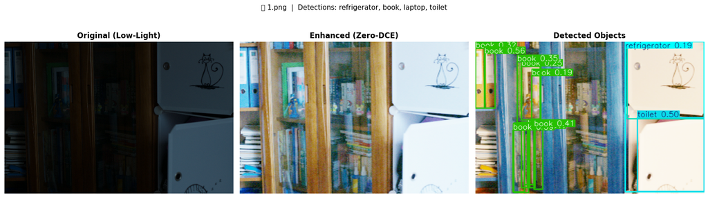

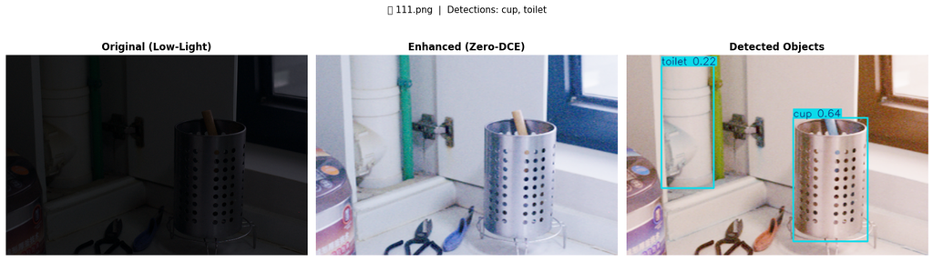

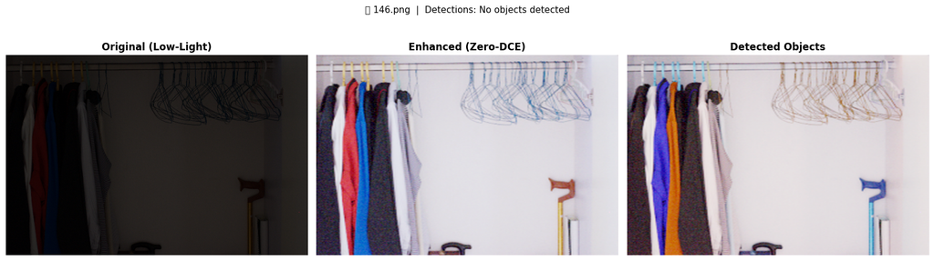

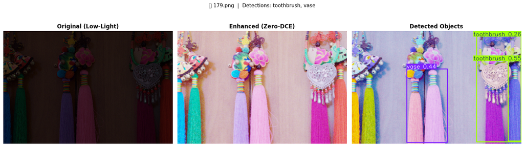

[figure not shown]

```python
test_files = glob.glob(TEST_DIR + "/*.png")
print(f"🔍 Processing {min(5, len(test_files))} test images...\n")

for f in test_files[:5]:
    orig_pil, enhanced_np = infer(f)
    annotated, results    = detect_on_enhanced(enhanced_np)

    detected_labels = []
    if results.boxes is not None and len(results.boxes):
        class_ids       = results.boxes.cls.cpu().numpy().astype(int)
        detected_labels = [yolo_model.names[c] for c in class_ids]
    label_str = ", ".join(set(detected_labels)) if detected_labels else "No objects detected"

    fig, axes = plt.subplots(1, 3, figsize=(16, 5))
    axes[0].imshow(orig_pil);     axes[0].set_title("Original (Low-Light)",  fontweight="bold"); axes[0].axis("off")
    axes[1].imshow(enhanced_np);  axes[1].set_title("Enhanced (Zero-DCE)",   fontweight="bold"); axes[1].axis("off")
    axes[2].imshow(annotated);    axes[2].set_title(f"Detected Objects",      fontweight="bold"); axes[2].axis("off")
    plt.suptitle(f"📂 {os.path.basename(f)}  |  Detections: {label_str}", fontsize=11)
    plt.tight_layout()
    plt.show()
```

### 📌 Cell 15 — Save Batch Results & Detection Log

**What it does:** Saves enhanced + annotated images and a JSON detection log (bounding boxes, confidence scores, class names) to `results_yolo/`.

```python
os.makedirs("results_yolo", exist_ok=True)
detection_summary = {}

for i, f in enumerate(test_files):
    _, enhanced_np        = infer(f)
    annotated, results    = detect_on_enhanced(enhanced_np)

    Image.fromarray(annotated).save(f"results_yolo/annotated_{i}.png")
    Image.fromarray((enhanced_np * 255).astype(np.uint8)).save(f"results_yolo/enhanced_{i}.png")

    detections = []
    if results.boxes is not None and len(results.boxes):
        for box, conf, cls in zip(
            results.boxes.xyxy.cpu().numpy(),
            results.boxes.conf.cpu().numpy(),
            results.boxes.cls.cpu().numpy()
        ):
            detections.append({
                "class": yolo_model.names[int(cls)],
                "confidence": round(float(conf), 3),
                "bbox_xyxy": [round(float(v), 1) for v in box]
            })

    detection_summary[os.path.basename(f)] = detections
    print(f"[{i+1:>2}/{len(test_files)}] {os.path.basename(f)} → {len(detections)} object(s)")

with open("results_yolo/detections_log.json", "w") as jf:
    json.dump(detection_summary, jf, indent=2)

print("\n✅ All results saved to /results_yolo/")
print("✅ Detection log saved to /results_yolo/detections_log.json")
```

```
[ 1/15] 1.png → 14 object(s)
[ 2/15] 111.png → 2 object(s)
[ 3/15] 146.png → 0 object(s)
[ 4/15] 179.png → 3 object(s)
[ 5/15] 22.png → 2 object(s)
[ 6/15] 23.png → 3 object(s)
[ 7/15] 493.png → 6 object(s)
[ 8/15] 547.png → 2 object(s)
[ 9/15] 55.png → 0 object(s)
[10/15] 665.png → 5 object(s)
[11/15] 669.png → 1 object(s)
[12/15] 748.png → 9 object(s)
[13/15] 778.png → 0 object(s)
[14/15] 780.png → 0 object(s)
[15/15] 79.png → 6 object(s)

✅ All results saved to /results_yolo/
✅ Detection log saved to /results_yolo/detections_log.json
```

### 📌 Cell 16 — Detection Summary Statistics

**What it does:** Counts detected object classes across the entire test set and plots a sorted bar chart of class frequencies.

> **What to look for:** If the same class dominates (e.g. "person" in 90% of detections), the test set may have a class imbalance. Very low detection counts overall may indicate the enhancement still isn't bright enough for YOLO to find objects reliably.

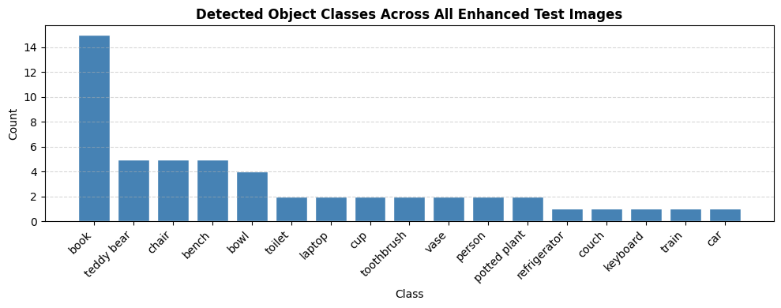

```
📊 Total detections : 53
📦 Unique classes   : 17

   book                   15
   teddy bear             5
   chair                  5
   bench                  5
   bowl                   4
   toilet                 2
   laptop                 2
   cup                    2
   toothbrush             2
   vase                   2
   person                 2
   potted plant           2
   refrigerator           1
   couch                  1
   keyboard               1
   train                  1
   car                    1
```

```python
from collections import Counter

all_classes = [d["class"] for dets in detection_summary.values() for d in dets]

if all_classes:
    class_counts  = Counter(all_classes)
    labels_sorted = sorted(class_counts, key=class_counts.get, reverse=True)
    counts_sorted = [class_counts[l] for l in labels_sorted]

    plt.figure(figsize=(10, 4))
    plt.bar(labels_sorted, counts_sorted, color="steelblue", edgecolor="white")
    plt.title("Detected Object Classes Across All Enhanced Test Images", fontweight="bold")
    plt.xlabel("Class")
    plt.ylabel("Count")
    plt.xticks(rotation=45, ha="right")
    plt.tight_layout()
    plt.grid(axis="y", linestyle="--", alpha=0.5)
    plt.show()

    print(f"\n📊 Total detections : {len(all_classes)}")
    print(f"📦 Unique classes   : {len(class_counts)}")
    print()
    for cls, cnt in class_counts.most_common():
        print(f"   {cls:<22} {cnt}")
else:
    print("⚠️  No objects detected. Try lowering conf=0.25 → conf=0.10 in detect_on_enhanced()")
```

## 🖥️ PHASE 5 (Interactive) — GUI: Upload Your Own Image

> **About the GUI cells:** These cells build an interactive interface using either `ipywidgets` (notebook-based) or `tkinter` (native OS window). They are demonstration / deployment cells — no new deep learning concepts are introduced, but they wrap the `infer()` and `detect_on_enhanced()` functions from Phase 5 into a user-friendly interface.

### 📌 Cell 17 — Install ipywidgets

**What it does:** Installs `ipywidgets` for the notebook-embedded upload button. Run once.

```python
subprocess.run([sys.executable, "-m", "pip", "install", "ipywidgets", "--quiet"], check=True)
print("✅ ipywidgets ready")
```

```
✅ ipywidgets ready
```

### 📌 Cell 18 — Interactive Enhancement & Detection GUI (Notebook Widget)

**What it does:** Creates an upload button in the notebook. Click → pick any low-light image → see original, enhanced, and YOLO-detected side by side.

**How to use:**

1. Click **📁 Select Image & Run**
2. A file picker window opens — select any `.png` or `.jpg`
3. Results appear instantly below

```python
# ============================================================
# CELL 18 — Interactive GUI with Separate File Dialog Window
# Uses tkinter to open a real OS file picker window
# ============================================================

import tkinter as tk
from tkinter import filedialog
import ipywidgets as widgets
from IPython.display import display, clear_output
import io

out        = widgets.Output()
status_lbl = widgets.Label(value="Click the button to open the file picker.")

def run_pipeline(btn):
    with out:
        clear_output(wait=True)

        root = tk.Tk()
        root.withdraw()
        root.call('wm', 'attributes', '.', '-topmost', True)

        filepath = filedialog.askopenfilename(
            title="Select a Low-Light Image",
            filetypes=[("Image files", "*.png *.jpg *.jpeg"), ("All files", "*.*")]
        )
        root.destroy()

        if not filepath:
            print("⚠️  No file selected.")
            status_lbl.value = "← No file selected."
            return

        filename = os.path.basename(filepath)
        status_lbl.value = f"Processing: {filename} ..."

        print(f"📂 File : {filepath}")

        pil_img = Image.open(filepath).convert("RGB")
        print(f"📐 Size : {pil_img.size[0]} × {pil_img.size[1]} px\n")

        _, enhanced_np = infer(pil_img)
        print("✅ Enhancement complete")

        annotated, results = detect_on_enhanced(enhanced_np)
        print("✅ Detection complete\n")

        detected_labels = []
        if results.boxes is not None and len(results.boxes):
            for cid, cf in zip(results.boxes.cls.cpu().numpy().astype(int),
                               results.boxes.conf.cpu().numpy()):
                detected_labels.append(f"{yolo_model.names[cid]} ({cf:.0%})")

        label_str = ", ".join(detected_labels) if detected_labels else "No objects detected"

        fig, axes = plt.subplots(1, 3, figsize=(17, 5))
        fig.patch.set_facecolor("#1a1a2e")
        for ax in axes:
            ax.set_facecolor("#1a1a2e")

        axes[0].imshow(pil_img)
        axes[0].set_title("Original (Low-Light)", color="white",   fontsize=12, fontweight="bold", pad=10)
        axes[0].axis("off")

        axes[1].imshow(enhanced_np)
        axes[1].set_title("Enhanced — Zero-DCE", color="#00d4aa", fontsize=12, fontweight="bold", pad=10)
        axes[1].axis("off")

        axes[2].imshow(annotated)
        axes[2].set_title("YOLOv8 Detections",   color="#f5a623", fontsize=12, fontweight="bold", pad=10)
        axes[2].axis("off")

        plt.suptitle(f"🔍 {label_str}", color="white", fontsize=11, y=1.01)
        plt.tight_layout()
        plt.show()

        if results.boxes is not None and len(results.boxes):
            print(f"{'#':<4} {'Class':<22} {'Confidence':<14} {'Bounding Box  (x1, y1, x2, y2)'}")
            print("─" * 70)
            for i, (box, conf, cls) in enumerate(zip(
                results.boxes.xyxy.cpu().numpy(),
                results.boxes.conf.cpu().numpy(),
                results.boxes.cls.cpu().numpy()
            )):
                name = yolo_model.names[int(cls)]
                bbox = f"({box[0]:.0f}, {box[1]:.0f}, {box[2]:.0f}, {box[3]:.0f})"
                print(f"{i+1:<4} {name:<22} {conf:.1%}{'':>6} {bbox}")
        else:
            print("ℹ️  No objects detected above confidence threshold.")

        os.makedirs("results_yolo", exist_ok=True)
        base     = os.path.splitext(filename)[0]
        Image.fromarray((enhanced_np * 255).astype(np.uint8)).save(f"results_yolo/user_{base}_enhanced.png")
        Image.fromarray(annotated).save(f"results_yolo/user_{base}_detected.png")
        status_lbl.value = f"✅ Done: {filename}"


run_btn = widgets.Button(
    description="📂 Select Image & Run",
    button_style="success",
    layout=widgets.Layout(width="220px", height="36px")
)
run_btn.on_click(run_pipeline)

display(widgets.VBox([
    widgets.HTML("""
    <div style='padding:16px 0 8px 0'>
      <h2 style='margin:0;color:#1a1a2e'>🌙 Low-Light Enhancement + Object Detection</h2>
      <p style='color:#555;margin:4px 0 0 0'>Click the button — a file picker window will open separately.</p>
    </div>
    """),
    widgets.HBox([run_btn, status_lbl],
                 layout=widgets.Layout(align_items="center", gap="12px")),
    widgets.HTML("<hr style='margin:10px 0'>"),
    out
]))
```

```
VBox(children=(HTML(value="\n    <div style='padding:16px 0 8px 0'>\n      <h2 style='margin:0;color:#1a1a2e'>…
```

### 📌 Cell 19 — NIGHTVISION Neon GUI (Standalone Tkinter Window)

**What it does:** Launches a full native OS window with a neon dark theme. More visually polished than the notebook widget.

```python
# ============================================================
# CELL 19 — NEON GUI (Opens in a separate Tkinter window)
# ============================================================

import tkinter as tk
from tkinter import filedialog
from PIL import Image, ImageTk, ImageDraw
import threading
import numpy as np
import os

def launch_neon_gui(infer, detect_on_enhanced, yolo_model):

    BG_DARK     = "#050510"
    BG_PANEL    = "#0a0a1a"
    BG_CARD     = "#0d0d20"
    NEON_CYAN   = "#00fff5"
    NEON_PINK   = "#ff006e"
    NEON_PURPLE = "#9d00ff"
    NEON_GREEN  = "#00ff88"
    NEON_YELLOW = "#ffe600"
    TEXT_DIM    = "#5a5a8a"
    BORDER_GLOW = "#1a1a3e"
    TITLE_BG    = "#111122"

    root = tk.Tk()
    root.title("⚡ NIGHTVISION — Low Light Enhancement + Detection")
    root.geometry("1200x820")
    root.configure(bg=BG_DARK)
    root.resizable(True, True)
    root.lift()
    root.attributes("-topmost", True)
    root.after(200, lambda: root.attributes("-topmost", False))

    def make_placeholder(w, h, color, label_text):
        img  = Image.new("RGB", (w, h), BG_CARD)
        draw = ImageDraw.Draw(img)
        draw.rectangle([2, 2, w-3, h-3], outline=color, width=2)
        draw.rectangle([6, 6, w-7, h-7], outline="#222244", width=1)
        cx, cy = w//2, h//2
        draw.line([(cx-20, cy), (cx+20, cy)], fill=color, width=2)
        draw.line([(cx, cy-20), (cx, cy+20)], fill=color, width=2)
        draw.ellipse([cx-4, cy-4, cx+4, cy+4], fill=color)
        draw.text((cx, h-24), label_text, fill=color, anchor="mm")
        return ImageTk.PhotoImage(img)

    hdr = tk.Frame(root, bg=BG_DARK, pady=0)
    hdr.pack(fill="x")
    title_frame = tk.Frame(hdr, bg=BG_DARK, pady=14)
    title_frame.pack(fill="x", padx=30)
    tk.Label(title_frame, text="⚡ NIGHTVISION",
             font=("Courier New", 28, "bold"),
             fg=NEON_CYAN, bg=BG_DARK).pack(side="left")
    tk.Label(title_frame,
             text="  //  LOW-LIGHT ENHANCEMENT  +  YOLO OBJECT DETECTION",
             font=("Courier New", 11), fg=TEXT_DIM, bg=BG_DARK).pack(side="left", padx=10)
    tk.Label(title_frame, text="Zero-DCE + YOLOv8s",
             font=("Courier New", 10), fg=NEON_PURPLE, bg=BG_DARK).pack(side="right")
    tk.Canvas(root, height=1, bg=BORDER_GLOW, highlightthickness=0).pack(fill="x")

    ctrl = tk.Frame(root, bg=BG_PANEL, pady=12)
    ctrl.pack(fill="x")
    inner_ctrl = tk.Frame(ctrl, bg=BG_PANEL)
    inner_ctrl.pack(padx=30)
    status_var = tk.StringVar(value="AWAITING INPUT  ·  SELECT AN IMAGE TO BEGIN")
    file_var   = tk.StringVar(value="")

    def make_neon_btn(parent, text, color, command, width=22):
        f = tk.Frame(parent, bg=color, padx=1, pady=1)
        btn = tk.Button(f, text=text, font=("Courier New", 11, "bold"),
                        fg=color, bg=BG_DARK, activeforeground=BG_DARK,
                        activebackground=color, relief="flat", cursor="hand2",
                        width=width, pady=8, command=command)
        btn.pack()
        f.pack(side="left", padx=8)
        return btn

    def on_select():
        filepath = filedialog.askopenfilename(
            title="Select Low-Light Image",
            filetypes=[("Images", "*.png *.jpg *.jpeg"), ("All", "*.*")]
        )
        if filepath:
            file_var.set(filepath)
            status_var.set(f"LOADED  ·  {os.path.basename(filepath)}")
            show_original(filepath)

    def on_run():
        fp = file_var.get()
        if not fp:
            status_var.set("⚠  NO FILE SELECTED")
            return
        t = threading.Thread(target=run_pipeline, args=(fp,), daemon=True)
        t.start()

    make_neon_btn(inner_ctrl, "◈  SELECT  IMAGE",      NEON_CYAN, on_select, width=20)
    make_neon_btn(inner_ctrl, "▶  ENHANCE  +  DETECT", NEON_PINK, on_run,    width=24)
    tk.Label(inner_ctrl, textvariable=file_var, font=("Courier New", 9),
             fg=TEXT_DIM, bg=BG_PANEL, width=50, anchor="w").pack(side="left", padx=12)

    status_frame = tk.Frame(root, bg=BG_DARK, pady=4)
    status_frame.pack(fill="x")
    status_dot = tk.Label(status_frame, text="●", font=("Courier New", 10),
                          fg=NEON_GREEN, bg=BG_DARK)
    status_dot.pack(side="left", padx=(30, 6))
    tk.Label(status_frame, textvariable=status_var,
             font=("Courier New", 10), fg=NEON_GREEN, bg=BG_DARK).pack(side="left")

    panels_frame = tk.Frame(root, bg=BG_DARK)
    panels_frame.pack(fill="both", expand=True, padx=20, pady=10)
    IMG_W, IMG_H = 340, 300

    def make_panel(parent, title, accent):
        frame = tk.Frame(parent, bg=BG_CARD,
                         highlightbackground=accent, highlightthickness=1)
        frame.pack(side="left", fill="both", expand=True, padx=8)
        title_bar = tk.Frame(frame, bg=TITLE_BG, pady=6)
        title_bar.pack(fill="x")
        tk.Label(title_bar, text=title, font=("Courier New", 10, "bold"),
                 fg=accent, bg=TITLE_BG).pack()
        canvas = tk.Canvas(frame, width=IMG_W, height=IMG_H,
                           bg=BG_CARD, highlightthickness=0)
        canvas.pack(pady=8, padx=8)
        info_var = tk.StringVar(value="─" * 30)
        tk.Label(frame, textvariable=info_var, font=("Courier New", 8),
                 fg=TEXT_DIM, bg=BG_CARD, wraplength=320, justify="left",
                 pady=4).pack(padx=10, anchor="w")
        ph = make_placeholder(IMG_W, IMG_H, accent, title)
        canvas.create_image(0, 0, anchor="nw", image=ph)
        canvas._ph = ph
        return canvas, info_var

    c_orig, info_orig = make_panel(panels_frame, "[ ORIGINAL  INPUT ]",    NEON_CYAN)
    c_enh,  info_enh  = make_panel(panels_frame, "[ ZERO-DCE  ENHANCED ]", NEON_GREEN)
    c_det,  info_det  = make_panel(panels_frame, "[ YOLO  DETECTIONS ]",   NEON_PINK)

    log_outer = tk.Frame(root, bg=BG_DARK)
    log_outer.pack(fill="x", padx=20, pady=(0, 14))
    tk.Label(log_outer, text="DETECTION LOG", font=("Courier New", 9, "bold"),
             fg=NEON_YELLOW, bg=BG_DARK).pack(anchor="w", pady=(0, 4))
    log_frame = tk.Frame(log_outer, bg=BG_CARD,
                         highlightbackground=NEON_YELLOW, highlightthickness=1)
    log_frame.pack(fill="x")
    log_text = tk.Text(log_frame, height=5, font=("Courier New", 9),
                       fg=NEON_YELLOW, bg=BG_CARD, insertbackground=NEON_YELLOW,
                       relief="flat", padx=12, pady=8, state="disabled")
    log_text.pack(fill="x")

    def log(msg):
        log_text.config(state="normal")
        log_text.insert("end", msg + "\n")
        log_text.see("end")
        log_text.config(state="disabled")

    def log_clear():
        log_text.config(state="normal")
        log_text.delete("1.0", "end")
        log_text.config(state="disabled")

    def show_on_canvas(canvas, pil_img):
        pil_img = pil_img.resize((IMG_W, IMG_H), Image.LANCZOS)
        tk_img  = ImageTk.PhotoImage(pil_img)
        canvas.create_image(0, 0, anchor="nw", image=tk_img)
        canvas._ph = tk_img

    def show_original(filepath):
        img = Image.open(filepath).convert("RGB")
        root.after(0, lambda: show_on_canvas(c_orig, img))
        root.after(0, lambda: info_orig.set(
            f"File: {os.path.basename(filepath)}  |  Size: {img.size[0]}×{img.size[1]}"
        ))

    def run_pipeline(filepath):
        root.after(0, lambda: status_var.set("ENHANCING  ·  ZERO-DCE RUNNING ..."))
        root.after(0, lambda: status_dot.config(fg=NEON_YELLOW))
        log_clear()
        log(f"▶  Input : {filepath}")

        try:
            pil_img, enhanced_np = infer(filepath)
            enh_pil = Image.fromarray((enhanced_np * 255).astype(np.uint8))
            root.after(0, lambda: show_on_canvas(c_enh, enh_pil))
            root.after(0, lambda: info_enh.set(
                f"Enhanced → upscaled to {pil_img.size[0]}×{pil_img.size[1]}"
            ))
            log("✅  Zero-DCE enhancement complete")
            root.after(0, lambda: status_var.set("DETECTING  ·  YOLO RUNNING ..."))

            annotated_rgb, results = detect_on_enhanced(enhanced_np)
            ann_pil = Image.fromarray(annotated_rgb)
            root.after(0, lambda: show_on_canvas(c_det, ann_pil))

            detections = []
            if results.boxes is not None and len(results.boxes):
                for box, conf, cls in zip(
                    results.boxes.xyxy.cpu().numpy(),
                    results.boxes.conf.cpu().numpy(),
                    results.boxes.cls.cpu().numpy()
                ):
                    detections.append((yolo_model.names[int(cls)], conf, box))

            det_count = len(detections)
            root.after(0, lambda: info_det.set(
                f"{det_count} object(s) detected  |  conf ≥ 0.15  |  imgsz=640"
            ))
            log(f"✅  Detection complete — {det_count} object(s) found")
            log("")
            log(f"  {'#':<4} {'CLASS':<18} {'CONF':>6}   BBOX (x1 y1 x2 y2)")
            log(f"  {'─'*55}")
            for i, (name, conf, box) in enumerate(detections):
                bbox = f"({box[0]:.0f}, {box[1]:.0f}, {box[2]:.0f}, {box[3]:.0f})"
                log(f"  {i+1:<4} {name:<18} {conf:.0%}     {bbox}")

            if det_count == 0:
                log("  ⚠  No objects above threshold. Try a different image.")

            os.makedirs("results_yolo", exist_ok=True)
            base = os.path.splitext(os.path.basename(filepath))[0]
            enh_pil.save(f"results_yolo/user_{base}_enhanced.png")
            ann_pil.save(f"results_yolo/user_{base}_detected.png")
            log(f"\n💾  Saved → results_yolo/user_{base}_*.png")

            root.after(0, lambda: status_var.set(
                f"COMPLETE  ·  {det_count} OBJECT(S) DETECTED  ·  {os.path.basename(filepath)}"
            ))
            root.after(0, lambda: status_dot.config(fg=NEON_GREEN))

        except Exception as e:
            log(f"❌  ERROR: {e}")
            root.after(0, lambda: status_var.set(f"ERROR  ·  {str(e)[:60]}"))
            root.after(0, lambda: status_dot.config(fg=NEON_PINK))

    root.mainloop()


print("🚀 Launching NIGHTVISION GUI...")
launch_neon_gui(infer, detect_on_enhanced, yolo_model)
```

```
🚀 Launching NIGHTVISION GUI...
```